# AKFIN catch by fishery

Alberto Rovellini

9/1/2021

This document explores the data set Groundfish Total Catch by Fishery from AKFIN. See AKFIN_catch.Rmd for details on the data query from AKFIN.

Objectives are:

1. Understand what “Trip target group” means.
2. Get a sense of how many species we have.
3. Visualise aggregated catch by speies by NMFS area.
4. Map species and targets to the Atlantis groups and repeat.

```r
library(tidyverse)
library(sf)
library(viridis)
library(lubridate)
```

```r
library(maps)
library(mapdata)
library(data.table)
```

Read all files.

```r
all_files <- list.files('AKFIN/Catch/by_fisheries/',full.names = TRUE)
file_list <- lapply(all_files, read.csv,fileEncoding='UTF-8-BOM')
catch_byf <- rbindlist(file_list)

glimpse(catch_byf)
```

```
## Rows: 1,617,473
## Columns: 30
## $ Year                      <int> 1991, 1991, 1991, 1991, 1991, 1991, 1991, 19~
## $ Week.Ending.Date          <chr> "1991-01-06", "1991-01-06", "1991-01-06", "1~
## $ Week.Number               <int> 2, 2, 2, 2, 2, 2, 2, 2, 2, 2, 2, 2, 2, 2, 2,~
## $ WED..mmdd.                <int> 106, 106, 106, 106, 106, 106, 106, 106, 106,~
## $ Detail.Record.Count       <int> 1, 1, 1, 1, 1, 1, 1, 1, 1, 1, 1, 1, 1, 1, 1,~
## $ Date.Received.from.AKR    <chr> "2009-05-27 09:29:39", "2009-05-27 09:29:39"~
## $ Date.Loaded.to.Repository <chr> "2021-04-01 16:35:57", "2021-04-01 16:35:57"~
## $ Processor.Federal.Permit  <chr> "2008", "2018", "2018", "2018", "2018", "369~
## $ Processor.Vessel.Name     <chr> "BLUE STAR", "TREMONT", "TREMONT", "TREMONT"~
## $ Processor.Name            <chr> "\"Star Offshore Inc\"", "\"New Wave Fisheri~
## $ Processor.Plant.Operation <chr> "FCP", "FCP", "FCP", "FCP", "FCP", "FCP", "F~
## $ Vessel.ADFG               <int> 41040, 55466, 55466, 55466, 55466, 59376, 59~
## $ Vessel.Name               <chr> "BLUE STAR", "TREMONT", "TREMONT", "TREMONT"~
```

[output cut: 17 more lines]

What are the targets here?

```r
all_target_groups <- catch_byf %>% select(Trip.Target.Group) %>% distinct() %>% pull()
all_target_names <- catch_byf %>% select(Trip.Target.Name) %>% distinct() %>% pull()

all_target_groups
```

```
## [1] "No Retained Groundfish" "Pollock"                "Flatfish"
## [4] "Pacific Cod"            "Other"                  "Rockfish"
## [7] "Sablefish"              "Atka Mackerel"          "Halibut"
```

```r
all_target_names
```

```
##  [1] ""                             "Pollock - midwater"
##  [3] "Deep Water Flatfish - GOA"    "Pacific Cod"
##  [5] "Shallow Water Flatfish - GOA" "Other Species"
##  [7] "Pollock - bottom"             "Rockfish"
##  [9] "Sablefish"                    "Arrowtooth Flounder"
## [11] "Rex Sole - GOA"               "Flathead Sole"
## [13] "Atka Mackerel"                "No retained catch"
## [15] "Halibut"
```

Target groups are limited to main groundfish species. What are the gears?

```r
all_gears <- catch_byf %>% select(Gear) %>% distinct() %>% pull()
all_gears
```

```
##  [1] "HAL" "TRW" "POT" "JIG" "GLN" "NUL" "OTH" " BT" "BTR" "PTR" "NPT"
```

```r
catch_byf %>% filter(Trip.Target.Name=="Pollock - midwater") %>% select(Gear) %>% distinct() %>% pull()
```

```
## [1] "TRW" "PTR" "BTR" "NPT" "POT" "HAL" "JIG" "OTH"
```

Gear names in the oberver data seem to be less cryptic (e.g. there is a long name field).

What are the species recorded in the catch data?

```r
all_species_groups <- catch_byf %>% select(Species.Group) %>% distinct() %>% pull()
all_species <- catch_byf %>% select(Species) %>% distinct() %>% pull()

all_species_groups
```

```
##  [1] "Pacific Cod"
##  [2] "Other"
##  [3] "Pacific Ocean Perch"
##  [4] "Pelagic Shelf Rockfish"
##  [5] "Pollock"
##  [6] "Shallow Water Flatfish"
##  [7] "Arrowtooth Flounder"
##  [8] "Deep Water Flatfish"
##  [9] "Sablefish"
## [10] "Shortraker/Rougheye Rockfish"
## [11] "Demersal Shelf Rockfish"
## [12] "Slope Rockfish"
## [13] "Flathead Sole"
## [14] "Other Slope Rockfish"
## [15] "Atka Mackerel"
```

[output cut: 36 more lines]

```r
all_species
```

```
##   [1] "\"cod, Pacific (gray)\""
##   [2] "\"groundfish, general\""
##   [3] "\"perch, Pacific ocean\""
##   [4] "\"rockfish, unspecified pelagic\""
##   [5] "\"pollock, walleye\""
##   [6] "\"flatfish, shallow water\""
##   [7] "\"flounder, arrowtooth\""
##   [8] "\"flatfish, deep water\""
##   [9] "\"sablefish (blackcod)\""
##  [10] "\"rockfish, shortraker/rougheye\""
##  [11] "\"rockfish, unspecified demersal\""
##  [12] "\"rockfish, unspecified slope\""
##  [13] "\"sole, flathead\""
##  [14] "\"greenling, atka mackerel\""
##  [15] "\"rockfish, thornyhead (idiots)\""
```

[output cut: 103 more lines]

# Map to NMFS areas

Let’s calculate monthly catch based on NMFS statistical areas. It seems that data from here matches data from the annual aggregated catch (see AKFIN_catch.Rmd for detials on that).

```r
catch_byf <- catch_byf %>% mutate(Month = month(Week.Ending.Date))

catch_by_month <- catch_byf %>% group_by(Year,Month,Species.Group,Species,FMP.Area,FMP.Subarea,NMFS.Area) %>% summarise(Catch = sum(Catch..mt.,na.rm=FALSE)) %>% ungroup() %>% mutate(Month.Year = make_date(year = Year, month = Month))
```

Plot over time, by year for ease of visualisation.

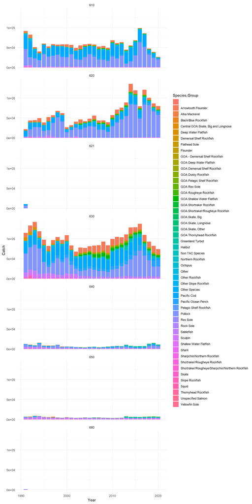

```r
catch_by_month %>%
  group_by(Year,Species.Group,Species,NMFS.Area) %>%
  summarise(Catch = sum(Catch, na.rm=TRUE)) %>%
  ungroup() %>%
  ggplot(aes(x=Year,y=Catch,fill=Species.Group))+
  geom_bar(stat='identity',position='stack')+
  theme_minimal()+
  guides(fill=guide_legend(ncol=1))+
  facet_wrap(~NMFS.Area, ncol=1)
```

Read in the shapefile for the NMFS areas.

```r
nmfs_sf <- st_read("gf95_nmfs/gf95_nmfs.shp")
```

```r
nmfs_sf <- nmfs_sf %>% filter(NMFS_AREA %in% (catch_byf %>% select(NMFS.Area) %>% distinct() %>% pull()))

#limits for plotting
nmfs_bbox <- nmfs_sf %>% st_bbox()

# add some coastline
coast <- maps::map(database = "worldHires", regions = c("Canada","US"), plot=FALSE, fill=TRUE)
coast_sf <- coast %>% st_as_sf(crs = 4326) %>% st_transform(crs=st_crs(nmfs_sf)$proj4string)
```

Plot for a species, by area, over time (years).

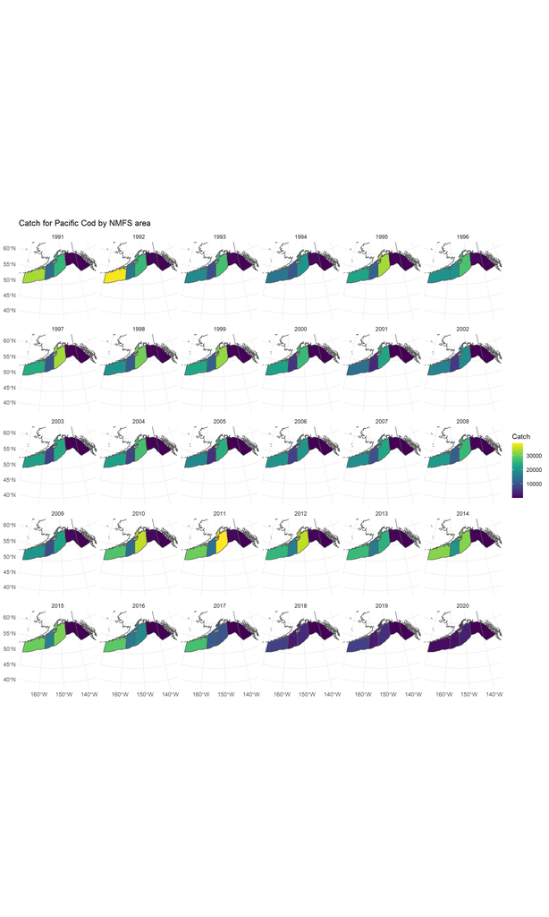

```r
this_species <- 'Pacific Cod'

nmfs_sf %>%
  left_join((catch_by_month %>%
               filter(Species.Group==this_species) %>%
               group_by(Year,Species.Group,Species,NMFS.Area) %>%
               summarise(Catch = sum(Catch, na.rm=TRUE)) %>%
               ungroup()),
            by=c('NMFS_AREA'='NMFS.Area')) %>%
  ggplot()+
  geom_sf(aes(fill=Catch))+
  scale_fill_viridis()+
  geom_sf(data=coast_sf,fill=NA)+
  coord_sf(xlim=c(nmfs_bbox$xmin,nmfs_bbox$xmax),ylim=c(nmfs_bbox$xmin,nmfs_bbox$xmax))+
  theme_minimal()+
  facet_wrap(~Year)+
  labs(title = paste("Catch for",this_species,"by NMFS area"))
```

This will need to be mapped to the Atlantis groups.